# R Notebook

## Introduction

For much of human existence, child birth has been an extraordinarily risky endeavor, often ending with the death of either the mother or baby. With the advent of modern medicine and technology, much of the world has seen a significant reduction in the rate of child berth related deaths and of child deaths. While this is something to applaud, there is still much work to be done. Child development after berth is a crucial period during which many of the neurological and motor skills necessary for a full and healthy life ossify. Anything parents can do to increase the healthiness of the baby in this period could have substantial effeccdts on a baby’s health. One avenue that might have a positive impact is during the actual pregnancy. Some women engage in prenatal activities that may be risky and others engage in prenatal activities that might be salubrious. In this study, We seek to determine whether prenatal care has an effect on the health of a newborn.

```r
library(car)
```

**Variable Descriptions:**

```r
load("bwght_w203.RData")
desc
```

| variable | label |
| --- | --- |
| mage | mother's age, years |
| meduc | mother's educ, years |
| monpre | month prenatal care began |
| npvis | total number of prenatal visits |
| fage | father's age, years |
| feduc | father's educ, years |
| bwght | birth weight, grams |
| omaps | one minute apgar score |
| fmaps | five minute apgar score |
| cigs | avg cigarettes per day |

[output cut: 13 more lines]

**Data Quality Assessment**

```r
# First we want to determine whether there are missing data. If there are, we will then want to determine whether
# there is a pattern to those missing data.
apply(data, 2, function(x) mean(is.na(x)))
```

```
       mage       meduc      monpre       npvis        fage       feduc       bwght       omaps       fmaps
0.000000000 0.016375546 0.002729258 0.037117904 0.003275109 0.025655022 0.000000000 0.001637555 0.001637555
       cigs       drink         lbw        vlbw        male       mwhte       mblck        moth       fwhte
0.060043668 0.062772926 0.000000000 0.000000000 0.000000000 0.000000000 0.000000000 0.000000000 0.000000000
      fblck        foth      lbwght      magesq     npvissq
0.000000000 0.000000000 0.000000000 0.000000000 0.037117904
```

**Exploratory Analysis of each variable:**

We start by looking at the independent variables available to measure level of prenatal care administered to mothers, as well as any variables that might be useful for controlling for other factors.

Age Variables:

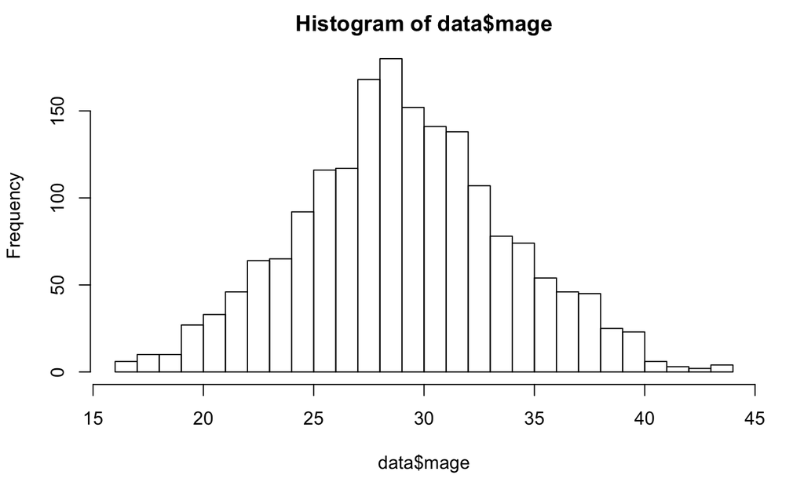

```r
hist(data$mage, breaks = 20)
```

```r
summary(data$fage)
```

```
   Min. 1st Qu.  Median    Mean 3rd Qu.    Max.    NA's
  18.00   28.00   31.00   31.92   35.00   64.00       6
```

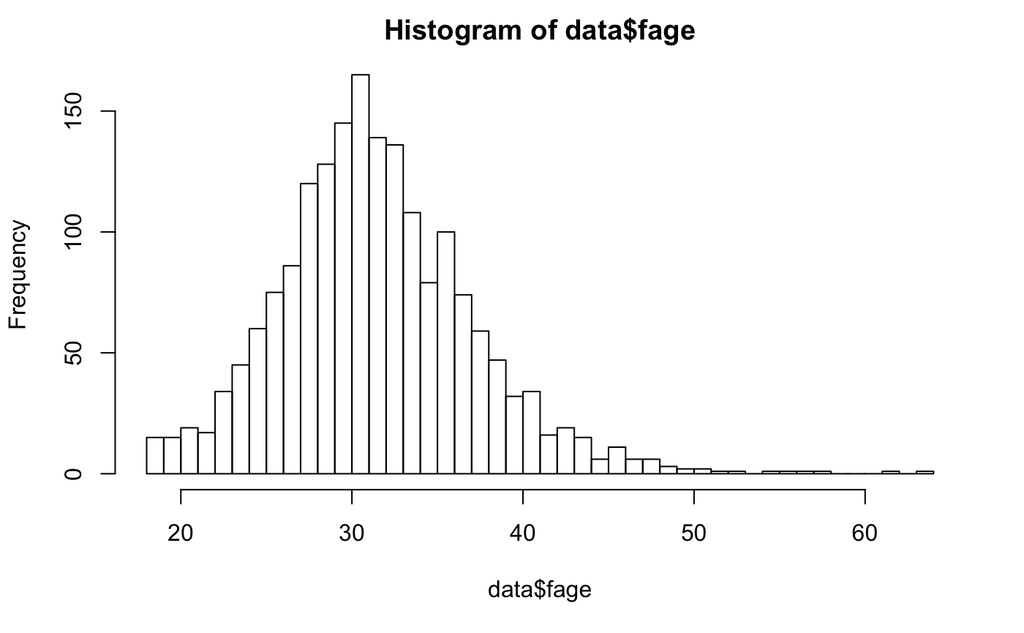

```r
hist(data$fage, breaks = 40)
```

```r
summary(data$fage)
```

```
   Min. 1st Qu.  Median    Mean 3rd Qu.    Max.    NA's
  18.00   28.00   31.00   31.92   35.00   64.00       6
```

The father and mother age variables both have fairly normal distributions around the 30-year mark, with the father age variable having a slight positive skew. This should mean that this dataset is fairly representative from an age perspective.

Education variables

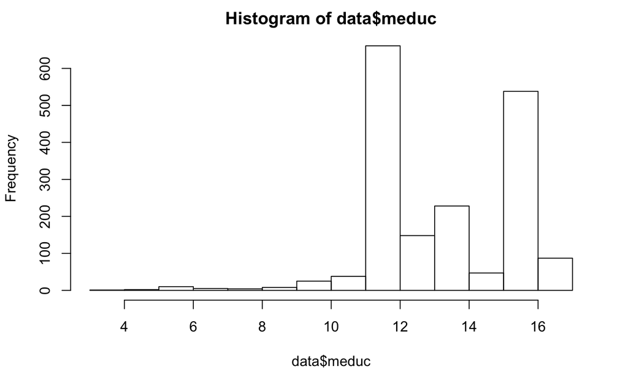

```r
hist(data$meduc)
```

```r
summary(data$meduc)
```

```
   Min. 1st Qu.  Median    Mean 3rd Qu.    Max.    NA's
   3.00   12.00   13.00   13.72   16.00   17.00      30
```

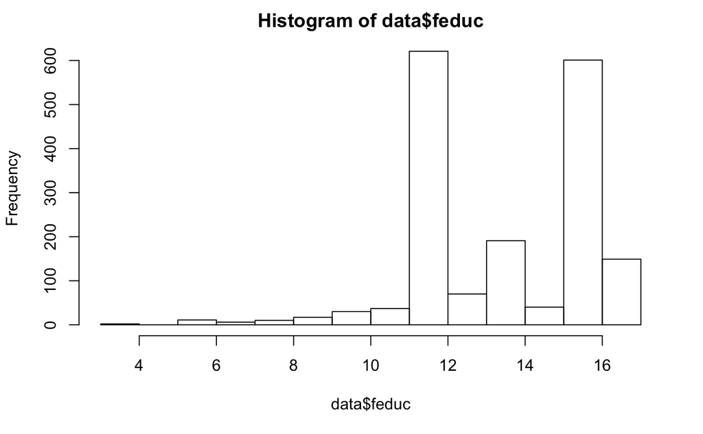

```r
hist(data$feduc)
```

```r
summary(data$feduc)
```

```
   Min. 1st Qu.  Median    Mean 3rd Qu.    Max.    NA's
   3.00   12.00   14.00   13.92   16.00   17.00      47
```

```r
cor(data[complete.cases(data$feduc) & complete.cases(data$meduc),]$feduc, data[complete.cases(data$feduc) & complete.cases(data$meduc),]$meduc)
```

```
[1] 0.5841373
```

Additionally, there is about 60% correlation between the education of the mother and father of each baby in the dataset, which aligns with the general notion that people marry others of the same education level.

Length of Prenatal Care

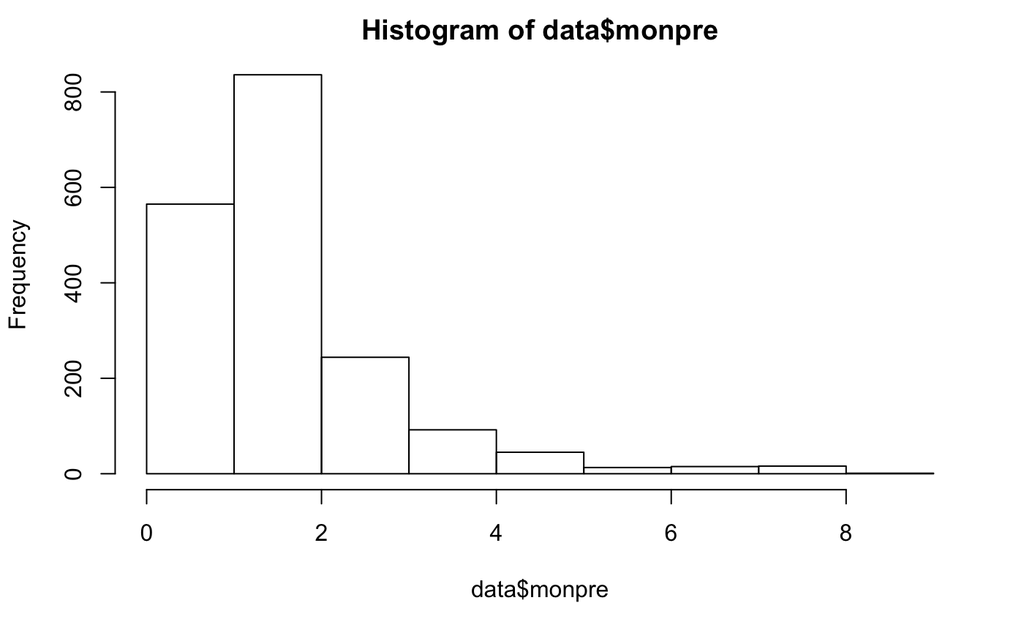

```r
hist(data$monpre, breaks = 9)
```

```r
summary(data$monpre)
```

```
   Min. 1st Qu.  Median    Mean 3rd Qu.    Max.    NA's
  0.000   1.000   2.000   2.122   2.000   9.000       5
```

The monpre variable signifies the month of pregnancy at which prenatal care started, and is one of the key variables we expect to help us predict infant health. Its range from zero to nine is sensible, although we don’t have anything to show us children that were born prematurely or later than nine months. In fact, such cases might be important because babies born prematurely tend to have smaller weight and face serious health risks. Therefore, the lack of this information might influence our conclusions.

Number of Prenatal Visits

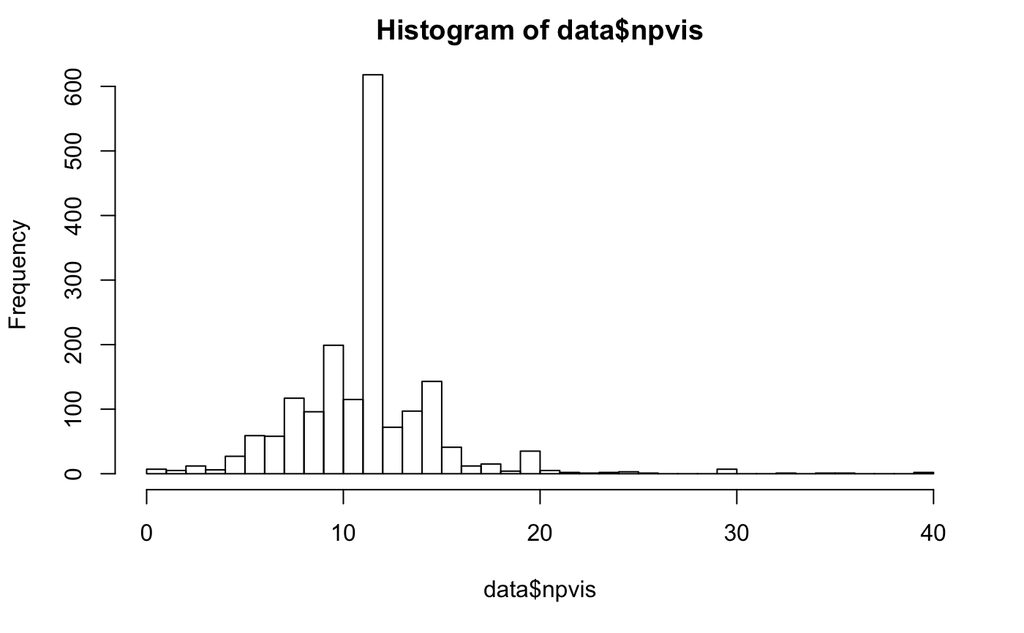

```r
hist(data$npvis, breaks = 40)
```

```r
summary(data$npvis)
```

```
   Min. 1st Qu.  Median    Mean 3rd Qu.    Max.    NA's
   0.00   10.00   12.00   11.62   13.00   40.00      68
```

The number of prenatal visits is another key metric we expect will have an effect on infant health. It has a strong positive skew, and we can see a peak at 12 visits. This could be because mothers that took part in this study were be eligible to a certain number of prenatal visits (possibly 12) for free, leading to a lot of women making exactly that many visits. The question of who pays for these visits could have a confounding effect, because it is more likely for mothers to make more visits if they are free and they would probably make less visits if they aren’t.

Plotting the number of visits to the month at which prenatal care started (see below), we can see two possible outliers in the top right. These two mothers had around 30 visits, even though they started their prenatal care in the 8th month. It could be the case that both of these mothers were admitted into hospital for a long period for a specific health problem, but we should check if these two points have an influence on the regression line of our models.

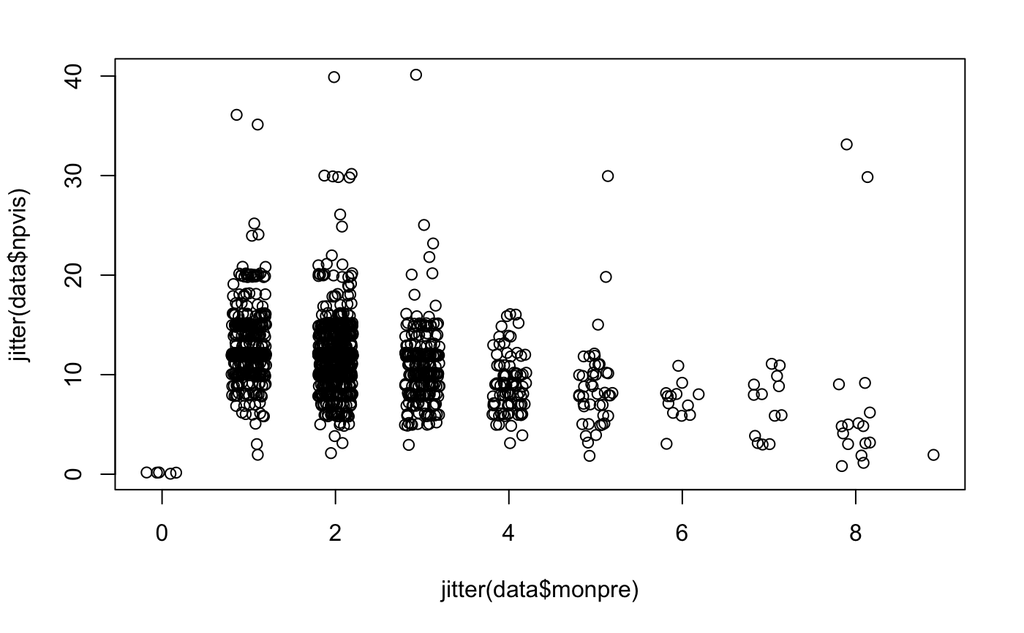

```r
plot(jitter(data$monpre), jitter(data$npvis))
```

Cigarettes

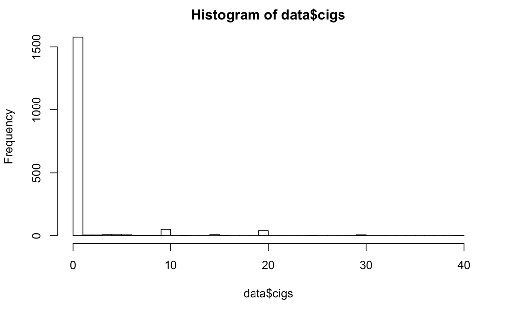

```r
hist(data$cigs, breaks = 40)
```

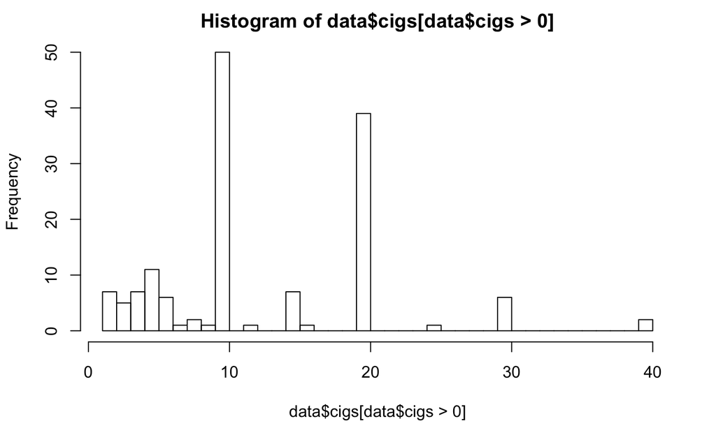

```r
hist(data$cigs[data$cigs > 0], breaks = 40)
```

```r
nrow(data[data$cigs > 0,])/nrow(data)
```

```
[1] 0.1402838
```

```r
summary(data$cigs)
```

```
   Min. 1st Qu.  Median    Mean 3rd Qu.    Max.    NA's
  0.000   0.000   0.000   1.089   0.000  40.000     110
```